# - Projected Models Overview

Kelsey Brock

03 March 2022

These represent model outputs of fire-promoting invasive plants species in Hawaii, generated based on code provided in https://github.com/kcbrock/HI-inv_spp-dist-public. All models are “in progress” and are being subjected to further evaluations to improve their accuracy.

```r
#get the needed packages
if(!require("pacman")){
    install.packages("pacman")
    library(pacman)}
p_load("dplyr", "PresenceAbsence", "DAAG", "ggplot2", 'tidyr', "raster", "sf", "knitr", "dismo", "gam", "randomForest", "gbm")
```

```r
# setting paths
path.root <- "~/codingwork/fire/"  # typical class root dir
```

```r
# handy projection string
prj.wgs84 <- "+proj=longlat +ellps=WGS84 +datum=WGS84 +no_defs"  # epsg:4326
```

```r
memory.limit(size=25000)
```

```
## [1] 25000
```

```r
future_clim <- "RCP8.5"
```

# Established & Well-known Fire-promoting Invasive Plants

## Cenchrus ciliaris - Bufflegrass

```r
spname = "Cenchrus_ciliaris"
```

### Projected Probability Model using Historic/Current Climate Data

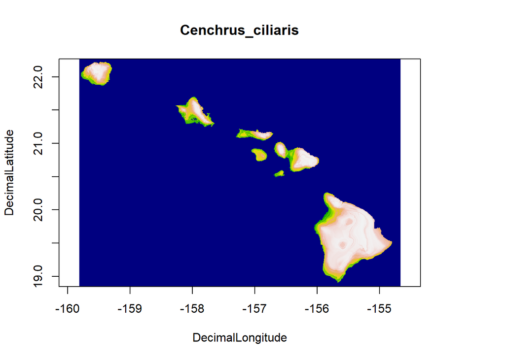

```r
path.specific <- paste(path.root, "/output/", spname, sep = "")
setwd(path.specific)
projected <- raster(paste0(spname, "_final_ensemble_raster.img"))
plot(projected, colNA = "navyblue", legend = FALSE, main = spname, ylab = "DecimalLatitude", xlab = "DecimalLongitude")
```

### Projected Probability Model using Future Climate Data

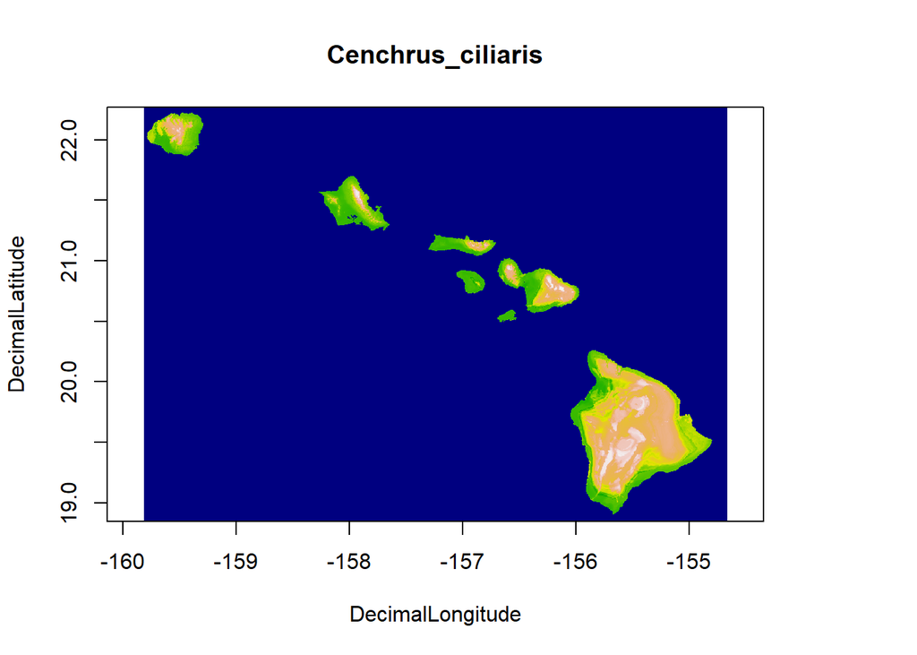

```r
path.specific <- paste(path.root, "/output/", spname, sep = "")
setwd(path.specific)
projected <- raster(paste0(spname, future_clim, "_final_ensemble_raster.img"))
plot(projected, colNA = "navyblue", legend = FALSE, main = spname, ylab = "DecimalLatitude", xlab = "DecimalLongitude")
```

Model Info:

Algorithms used: Created Ensemble Model of Generalized Linear Model (GLM), Generalized Additive Model (GAM), Maximum Entropy (MaxEnt), Random Forest (RF), Boosted Regression Trees (BRT)

No. of (filtered & thinned) global occurrence points: 705 No. of local (filtered & thinned) occurrence points: 50

Final Model Used: Local Ensemble Model informed by Global Ensemble Model

Model Stats:

Cutpoint (MaxKappa): 0.59 True Test Statistic [TSS]: 0.69 Receiver Operator Characteristic [ROC]): 0.89

## Cenchrus setaceus - Fountaingrass

```r
spname = "Cenchrus_setaceus"
```

### Projected Probability Model using Historic/Current Climate Data

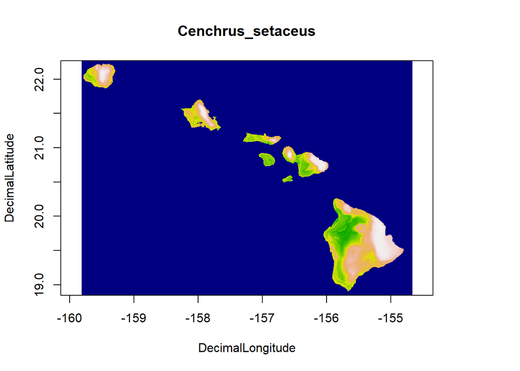

```r
path.specific <- paste(path.root, "/output/", spname, sep = "")
setwd(path.specific)
projected <- raster(paste0(spname, "_final_ensemble_raster.img"))
plot(projected, colNA = "navyblue", legend = FALSE, main = spname, ylab = "DecimalLatitude", xlab = "DecimalLongitude")
```

### Projected Probability Model using Future Climate Data

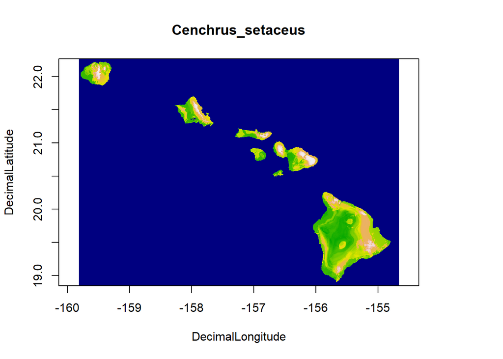

```r
path.specific <- paste(path.root, "/output/", spname, sep = "")
setwd(path.specific)
projected <- raster(paste0(spname, future_clim, "_final_ensemble_raster.img"))
plot(projected, colNA = "navyblue", legend = FALSE, main = spname, ylab = "DecimalLatitude", xlab = "DecimalLongitude")
```

Model Info:

Algorithms used: Created Ensemble Model of Generalized Linear Model (GLM), Generalized Additive Model (GAM), Maximum Entropy (MaxEnt), Random Forest (RF), Boosted Regression Trees (BRT)

No. of (filtered & thinned) global occurrence points: 647 No. of local (filtered & thinned) occurrence points: 76

Final Model Used: Local Ensemble Model informed by Global Ensemble Model

Model Stats:

Cutpoint (MaxKappa): 0.50 True Test Statistic [TSS]: 0.63 Receiver Operator Characteristic [ROC]): 0.85

## Melinis minutiflora - Molassesgrass

```r
spname = "Melinis_minutiflora"
```

### Projected Probability Model using Historic/Current Climate Data

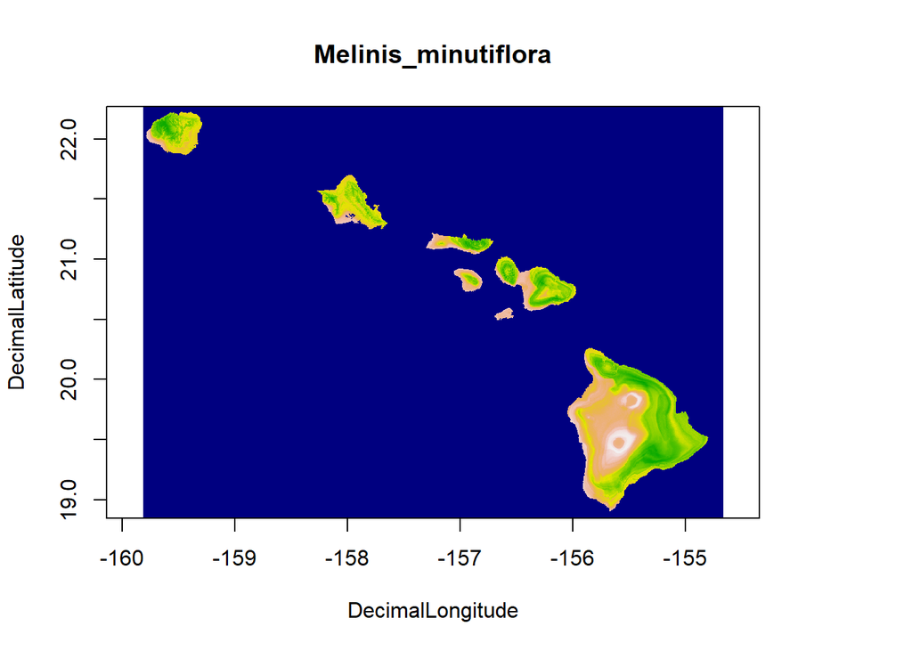

```r
path.specific <- paste(path.root, "/output/", spname, sep = "")
setwd(path.specific)
projected <- raster(paste0(spname, "_final_ensemble_raster.img"))
plot(projected, colNA = "navyblue", legend = FALSE, main = spname, ylab = "DecimalLatitude", xlab = "DecimalLongitude")
```

### Projected Probability Model using Future Climate Data

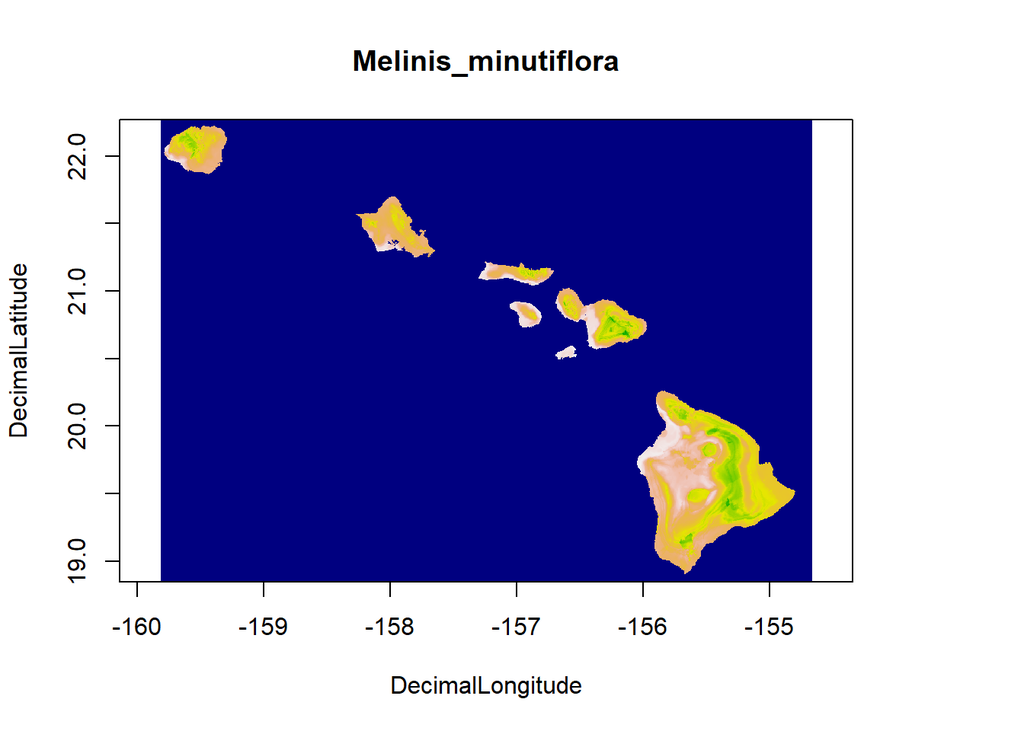

```r
path.specific <- paste(path.root, "/output/", spname, sep = "")
setwd(path.specific)
projected <- raster(paste0(spname, future_clim, "_final_ensemble_raster.img"))
plot(projected, colNA = "navyblue", legend = FALSE, main = spname, ylab = "DecimalLatitude", xlab = "DecimalLongitude")
```

Model Info:

Algorithms used: Created Ensemble Model of Generalized Linear Model (GLM), Generalized Additive Model (GAM), Maximum Entropy (MaxEnt), Random Forest (RF), Boosted Regression Trees (BRT)

No. of (filtered & thinned) global occurrence points: 330 No. of local (filtered & thinned) occurrence points: 73

Final Model Used: Local Ensemble Model informed by Global Ensemble Model

Model Stats:

Cutpoint (MaxKappa): 0.53 True Test Statistic [TSS]: 0.60 Receiver Operator Characteristic [ROC]): 0.84

## Megathyrsus maximus - Guineagrass

```r
spname = "Panicum_maximum"
```

### Projected Probability Model using Historic/Current Climate Data

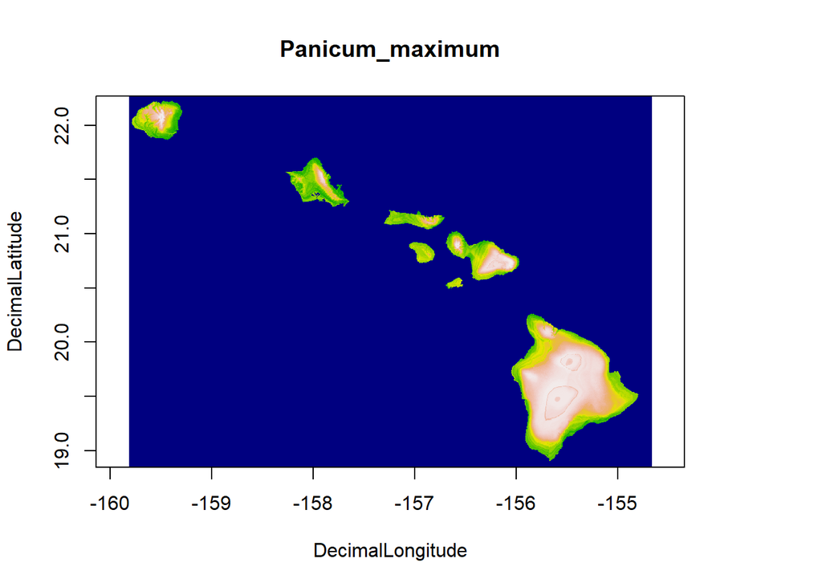

```r
path.specific <- paste(path.root, "/output/", spname, sep = "")
setwd(path.specific)
projected <- raster(paste0(spname, "_final_ensemble_raster.img"))
plot(projected, colNA = "navyblue", legend = FALSE, main = spname, ylab = "DecimalLatitude", xlab = "DecimalLongitude")
```

### Projected Probability Model using Future Climate Data

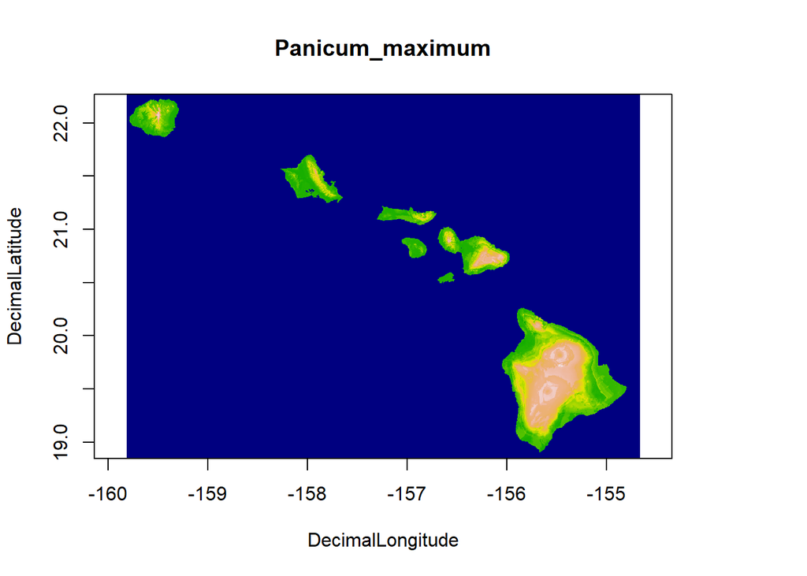

```r
path.specific <- paste(path.root, "/output/", spname, sep = "")
setwd(path.specific)
projected <- raster(paste0(spname, future_clim, "_final_ensemble_raster.img"))
plot(projected, colNA = "navyblue", legend = FALSE, main = spname, ylab = "DecimalLatitude", xlab = "DecimalLongitude")
```

Model Info:

Algorithms used: Created Ensemble Model of Generalized Linear Model (GLM), Generalized Additive Model (GAM), Maximum Entropy (MaxEnt), Random Forest (RF), Boosted Regression Trees (BRT)

No. of (filtered & thinned) global occurrence points: 1089 No. of local (filtered & thinned) occurrence points: 84

Final Model Used: Local Ensemble Model informed by Global Ensemble Model

Model Stats:

Cutpoint (MaxKappa): 0.58 True Test Statistic [TSS]: 0.66 Receiver Operator Characteristic [ROC]): 0.89

## Schizachyrium condensatum - Beardgrass

```r
spname = "Schizachyrium_condensatum"
```

### Projected Probability Model using Historic/Current Climate Data

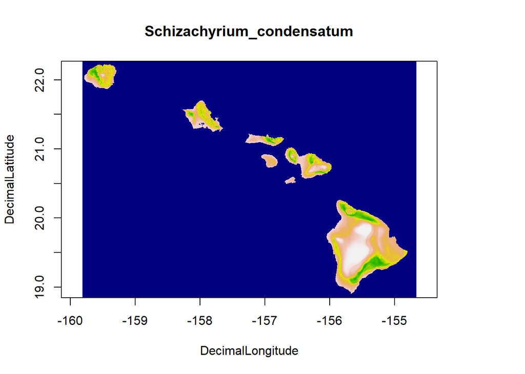

```r
path.specific <- paste(path.root, "/output/", spname, sep = "")
setwd(path.specific)
projected <- raster(paste0(spname, "_final_ensemble_raster.img"))
plot(projected, colNA = "navyblue", legend = FALSE, main = spname, ylab = "DecimalLatitude", xlab = "DecimalLongitude")
```

### Projected Probability Model using Future Climate Data

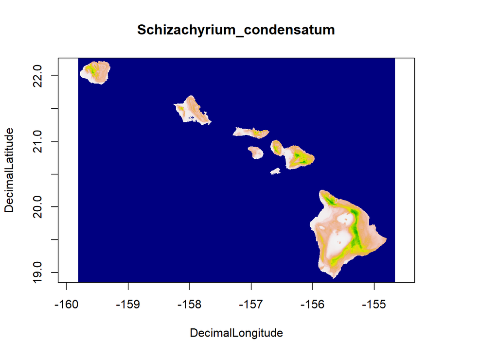

```r
path.specific <- paste(path.root, "/output/", spname, sep = "")
setwd(path.specific)
projected <- raster(paste0(spname, future_clim, "_final_ensemble_raster.img"))
plot(projected, colNA = "navyblue", legend = FALSE, main = spname, ylab = "DecimalLatitude", xlab = "DecimalLongitude")
```

Model Info:

Algorithms used: Created Ensemble Model of Generalized Linear Model (GLM), Generalized Additive Model (GAM), Maximum Entropy (MaxEnt), Random Forest (RF), Boosted Regression Trees (BRT)

No. of (filtered & thinned) global occurrence points: 262 No. of local (filtered & thinned) occurrence points: 27

Final Model Used: Local Ensemble Model informed by Global Ensemble Model

Model Stats:

Cutpoint (MaxKappa): 0.55 True Test Statistic [TSS]: 0.73 Receiver Operator Characteristic [ROC]): 0.91

## Ulex_europaeus - Gorse

```r
spname = "Ulex_europaeus"
```

### Projected Probability Model using Historic/Current Climate Data

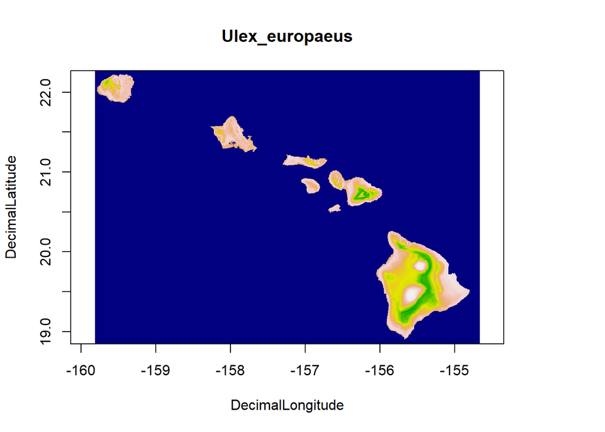

```r
path.specific <- paste(path.root, "/output/", spname, sep = "")
setwd(path.specific)
projected <- raster(paste0(spname, "_final_ensemble_raster.img"))
plot(projected, colNA = "navyblue", legend = FALSE, main = spname, ylab = "DecimalLatitude", xlab = "DecimalLongitude")
```

### Projected Probability Model using Future Climate Data

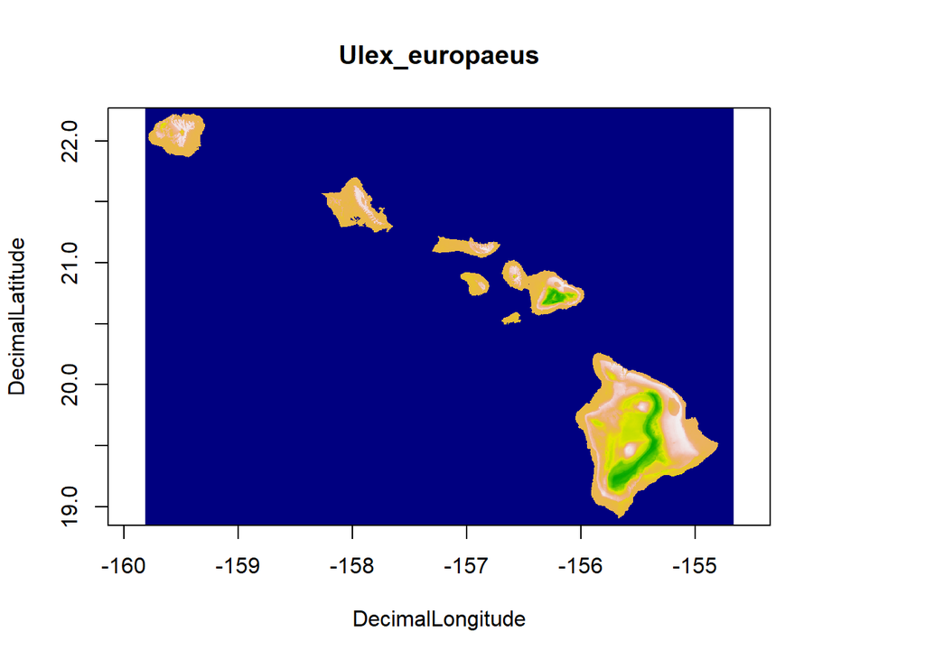

```r
path.specific <- paste(path.root, "/output/", spname, sep = "")
setwd(path.specific)
projected <- raster(paste0(spname, future_clim, "_final_ensemble_raster.img"))
plot(projected, colNA = "navyblue", legend = FALSE, main = spname, ylab = "DecimalLatitude", xlab = "DecimalLongitude")
```

Model Info:

Algorithms used: Created Ensemble Model of Generalized Linear Model (GLM), Generalized Additive Model (GAM), Maximum Entropy (MaxEnt), Random Forest (RF), Boosted Regression Trees (BRT)

No. of (filtered & thinned) global occurrence points: 411 No. of local (filtered & thinned) occurrence points: 40

Final Model Used: Local Ensemble Model informed by Global Ensemble Model

Model Stats:

Cutpoint (MaxKappa): 0.45 True Test Statistic [TSS]: 0.68 Receiver Operator Characteristic [ROC]): 0.85

# Incipient Fire-promoting Invasive Plants

## Andropogon_bicornis - West Indian Foxtail

```r
spname = "Andropogon_bicornis"
```

### Projected Probability Model using Historic/Current Climate Data

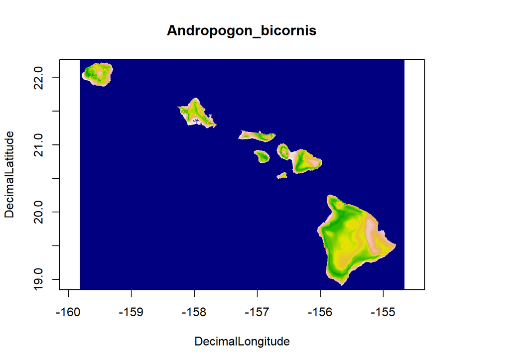

```r
path.specific <- paste(path.root, "/output/", spname, sep = "")
setwd(path.specific)
projected <- raster(paste0(spname, "_final_ensemble_raster.img"))
plot(projected, colNA = "navyblue", legend = FALSE, main = spname, ylab = "DecimalLatitude", xlab = "DecimalLongitude")
```

### Projected Probability Model using Future Climate Data

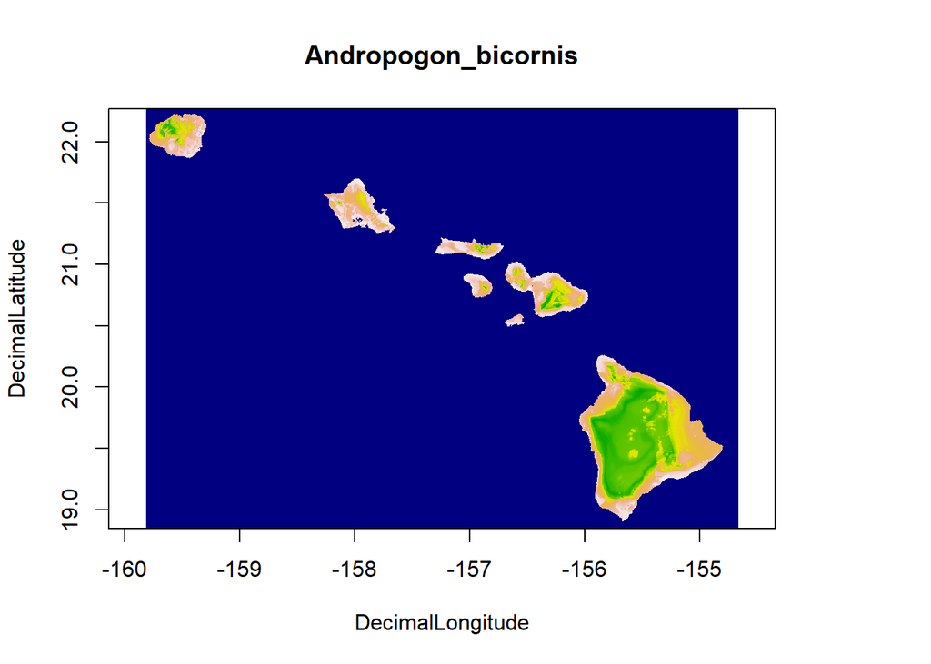

```r
path.specific <- paste(path.root, "/output/", spname, sep = "")
setwd(path.specific)
projected <- raster(paste0(spname, future_clim, "_final_ensemble_raster.img"))
plot(projected, colNA = "navyblue", legend = FALSE, main = spname, ylab = "DecimalLatitude", xlab = "DecimalLongitude")
```

Model Info:

Algorithms used: Created Ensemble Model of Generalized Linear Model (GLM), Generalized Additive Model (GAM), Maximum Entropy (MaxEnt), Random Forest (RF), Boosted Regression Trees (BRT)

No. of (filtered & thinned) global occurrence points: 616 No. of local (filtered & thinned) occurrence points: 21

Final Model Used: Local Ensemble Model informed by Global Ensemble Model

Model Stats:

Cutpoint (MaxKappa): 0.61 True Test Statistic [TSS]: 0.70 Receiver Operator Characteristic [ROC]): 0.90

## Chromolaena odorata - Devil Weed

```r
spname = "Chromolaena_odorata"
```

```r
path.specific <- paste(path.root, "/output/", spname, sep = "")
setwd(path.specific)
#projected <- raster(paste0(spname, "_final_ensemble_raster.img"))
#plot(projected, colNA = "navyblue", legend = FALSE, main = spname, ylab = "DecimalLatitude", xlab = "DecimalLongitude")
```

```r
path.specific <- paste(path.root, "/output/", spname, sep = "")
setwd(path.specific)
#projected <- raster(paste0(spname, future_clim, "_final_ensemble_raster.img"))
#plot(projected, colNA = "navyblue", legend = FALSE, main = spname, ylab = "DecimalLatitude", xlab = "DecimalLongitude")
```

Model Info:

Algorithms used: Created Ensemble Model of Generalized Linear Model (GLM), Generalized Additive Model (GAM), Maximum Entropy (MaxEnt), Random Forest (RF), Boosted Regression Trees (BRT)

Final Model Used: Local Ensemble Model informed by Global Ensemble Model

Model Stats: